### Red (PISCO)

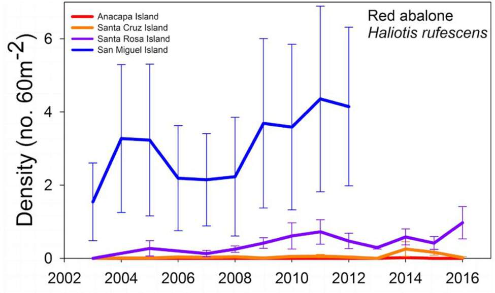

**Figure App.F.13.9.**. A figure showing the average density of red abalone across the Northern Channel Islands from 2003 - 2016.

**Click for Details**

Average density (+/- standard error) of red abalone *Haliotis rufescens* at 14 sites across four islands in Channel Islands National Marine Sanctuary monitored by the [PISCO](http://www.piscoweb.org/kelp-forest-sampling-protocols) kelp forest monitoring program from 2003–2016. Abalone are counted by SCUBA divers swimming along transect lines. Observed density was averaged across all monitoring sites at each island, including sites located inside and outside of marine reserves and conservation areas, to examine course-scale trends by island. Observed density was higher at San Miguel Island (blue). Data source: PISCO; Figure: [R. Freedman/NOAA](https://channelislands.noaa.gov/contact/freedman.html)

### Red (CINP)

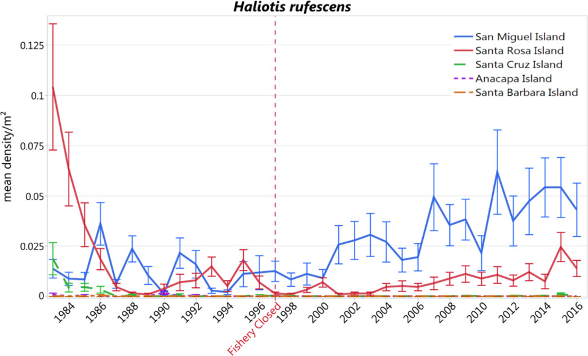

**Figure App.F.13.10a.**. A figure showing the average density of red abalone across the Northern Channel Islands from 1984 - 2016.

**Click for Details**

Average density of red abalone *Haliotis rufescens* at Channel Islands National Park kelp forest monitoring sites at the five islands in Channel Islands National Marine Sanctuary. Abundance of both species was greatly reduced by harvest at all islands prior to the fishery closure in 1997. A gradual increasing trend in abundance of red abalone has been observed since the fishery closure at San Miguel (blue) and more recently at Santa Rosa (red) islands. Abalone are counted by SCUBA divers and observed density was averaged across all monitoring sites at each island, including sites located inside and outside of marine reserves and conservation areas, to examine course-scale trends by island. Figure: [Channel Islands National Park](https://www.nps.gov/chis/index.htm)

### Pink (CINP)

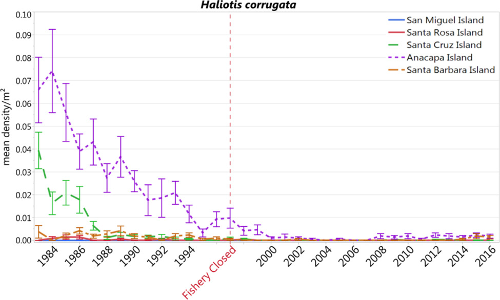

**Figure App.F.13.10b.**. A figure showing the average density of pink abalone across the Northern Channel Islands from 1984 - 2016.

**Click for Details**